# Exploration des données DHS

Présentation, accès et contenu des donnèes,

Hugues Pecout (CNRS, FR CIST)

[figure not shown]

# The DHS Program

Le [programme DHS](https://www.dhsprogram.com/) est un programme d’enquêtes démographiques et de santé (EDS) de l’[United States Agency for International Development](https://www.usaid.gov/).

**Ce programme a collecté, analysé et diffuse des données précises et représentatives sur la population, la santé, le VIH et la nutrition à travers plus de 400 enquêtes dans plus de 90 pays, depuis plus de 30 ans :**

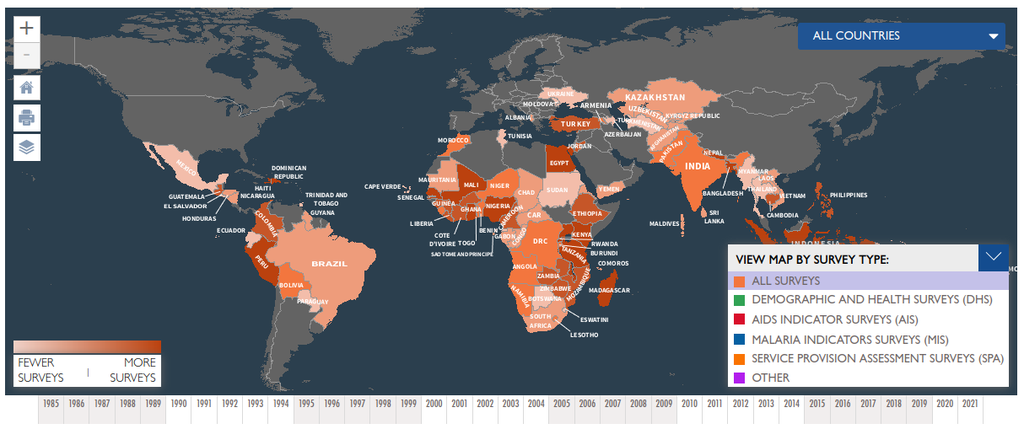

# 1 Les donnèes

L’accées aux données est gratuite, mais **il est obligatoire de** [**réaliser une demande justifiée**](https://dhsprogram.com/data/new-user-registration.cfm) **pour avoir d’un compte utilisateur permettant le téléchargement des données individuelles**.

**Seules des données aggrégés à des niveaux régionaux (départements pour le Bénin), et un jeu de données individuelles modèle (exemple) sont accessibles sans création de compte** **(cf partie 1.2)**.

## 1.1 Questionnaire DHS

Beaucoup de documentation sur les méthodes d’enquête et les donnèes est mis à disposition :

1. [**Guide to DHS Statistics** V7](https://dhsprogram.com/Data/Guide-to-DHS-Statistics/index.cfm)
2. [**Modèle de questionnaire** V6](https://www.dhsprogram.com/publications/publication-dhsq6-dhs-questionnaires-and-manuals.cfm)
3. [**Information sur les donnèes** V6](https://www.dhsprogram.com/publications/publication-dhsg4-dhs-questionnaires-and-manuals.cfm)

## 1.2 Jeu de données exemple

**Néanmoins, le programme DHS a créé des exemples d’ensembles de données individuelles avec lesquels les utilisateurs peuvent s’exercer**. Ces ensembles de données ont été créés strictement pour la pratique et ne représentent pas les données réelles d’un pays. Ces ensembles de données sont basés sur le questionnaire *DHS6* et *Recode*. **Vous n’avez pas besoin de vous inscrire pour télécharger ces données.**

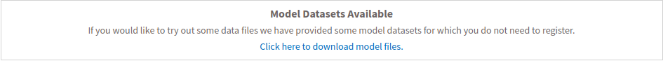

https://dhsprogram.com/data/Download-Model-Datasets.cfm

Les exemples exemples d’ensembles de données sont mis à disposition dans **quatre formats** :  
- *Stata dataset (.dta)*  
- *Flat ASCII data (.dat)*  
- *SAS dataset (.sas7bdat)*  
- *SPSS dataset (.sav)*

Et parfois en *Hierarchical ASCII data (.dat)*

Les données sont proposées aux téléchargement par groupes d’individus ou thématiques :  
- Births  
- Couple  
- Household  
- Individual  
- Children  
- Men  
- Household member  
- HIV Test results

**La localisation GPS des individus ne semble pas être fournie dans le jeu de donnèes exemple…**

### 1.2.1 Import des données exemple

**-> Test d’import des donnèes “household” au format SPSS (.sav) :**

```r
library(haven)
  data_ex <- read_sav("model/zzhr62sv/ZZHR62FL.SAV")
```

### 1.2.2 Liste des variables (avec label)

```r
# AFFICHER LE LABEL D'UNE VARIABLE
  attr(data_ex$HV028, "label")
```

```
[1] "Household weight for male subsample (6 decimals)"
```

```r
# AFFICHER LES LABELS DE TOUTES LES VARIABLES (Code + label)
  l <- lapply(data_ex, attr, "label")
  l <- as.data.frame(l, stringsAsFactors = F)
  list_var <- as.data.frame(t(l))

  library(DT)
  datatable(list_var, options = list(
                                          autoWidth = TRUE,
                                          rownames = FALSE,
                                          pageLength =NULL))
```

|  | V1 |
| --- | --- |
| HHID | Case Identification |
| HV000 | Country code and phase |
| HV001 | Cluster number |
| HV002 | Household number |
| HV003 | Respondent's line number (answering Household questionnaire) |
| HV004 | Ultimate area unit |
| HV005 | Household sample weight (6 decimals) |
| HV006 | Month of interview |
| HV007 | Year of interview |
| HV008 | Date of interview (CMC) |

[output cut: 7644 more lines]

### 1.2.3 Liste des modalités (avec label)

```r
# POUR UNE SEULE VARIABLE
  attr(data_ex[["HV023"]], "labels")
```

```
Region 1 - urban Region 1 - rural Region 2 - urban Region 2 - rural
                 1                2                3                4
  Region 3 - urban Region 3 - rural Region 4 - urban Region 4 - rural
                 5                6                7                8
```

```r
# POUR TOUTES LES VARIABLES
  library(sjlabelled)
  get_labels(data_ex)
```

[output not shown]

[output cut: 281 more lines]

[output not shown]

## 1.3 Couverture du Bénin

Le Bénin fait partie des [pays ciblés par les enquêtes](https://dhsprogram.com/Countries/). Dans le cadre de ce programme, [**l’enquête standard DHS a été réalisées 5 fois**](https://dhsprogram.com/methodology/survey-search.cfm?sendsearch=1&str1=52&crt=1&listgrp=3) sur ce pays, aux dates suivantes : **1996**, **2001**, **2006**, **2011-2012**, **2017-2018**.

Voici un aperçu de **quelques indicateurs collectés** (valeur nationnale) et leur **disponibilité par dates** :

|  | Indicator | 1996 | 2001 | 2006 | 2011-2012 | 2017-2018 |
| --- | --- | --- | --- | --- | --- | --- |
| 1 | Total fertility rate 15-49 | 6 | 5.6 | 5.7 | 4.9 | 5.7 |
| 2 | Married women currently using any method of contraception | 16.4 | 18.6 | 17 | 12.9 | 15.5 |
| 3 | Married women currently using any modern method of contraception | 3.4 | 7.2 | 6.1 | 7.9 | 12.4 |
| 4 | Unmet need for family planning | 27.7 | 27.9 | 27.3 | 32.6 | 32.3 |
| 5 | Demand for family planning satisfied by modern methods | 7.8 | 15.4 | 13.9 | 17.4 | 25.9 |
| 6 | Median age at first marriage [Women]: 25-49 | 18.4 | 18.8 | 18.6 | 19.8 | 19.4 |
| 7 | Median age at first sexual intercourse [Women]: 25-49 | 17.3 | 17.3 | 17.8 | 18.4 | 17.3 |
| 8 | Infant mortality rate | 94 (CI: 84 – 104) | 89 (CI: 80 – 98) | 67 (CI: 62 – 72) | 42 (CI: 38 – 46) | 55 (CI: 50 – 60) |
| 9 | Infant mortality rate | 103 (CI: 96 – 111) | 95 (CI: 88 – 102) | 76 (CI: 72 – 80) | 46 (CI: 42 – 49) | 60 (CI: 55 – 64) |
| 10 | Under-five mortality rate | 166 (CI: 154 – 179) | 160 (CI: 148 – 172) | 125 (CI: 118 – 132) | 70 (CI: 64 – 76) | 96 (CI: 90 – 103) |

[output cut: 20 more lines]

Il semblerait que **la localisation GPS des individus enquêtés ne soit pas disponible pour 2006**.

## 1.4 Indicateurs disponibles

**Le package R** [`rdhs`](https://docs.ropensci.org/rdhs/), développé par OJ.. Watson & J. Eaton et soutenu par [rOpenSCi](https://ropensci.org/), **permet d’accéder directement aux données avec R**.

**Ce package fournit un client pour :**

1. **Interroger l’API des donnèes DHS** pour les indicateurs et les métadonnées d’enquête
2. **Identifier les enquêtes et les ensembles de données** pour l’analyse
3. **Télécharger les ensembles de données d’enquête** à partir du site Web de l’EDS
4. **Charger les ensembles de données et les métadonnées associées** dans R
5. **Extraire les variables et combiner les ensembles de données** pour une analyse groupée l’accessibilité de ces ensembles de données pour l’analyse statistique avec R

**Il n’est pas nécéssaire d’avoir une compte utlisateur pour les étapes 1 et 2.** Il est donc possible d’explorer les données mises à disposition via R, sans s’enregistrer auprès du programme DHS

## 1.5 Le package `rdhs`

Pour récupérer à la table complète des indicateurs disponibles et à leurs caractèristiques :

```r
# install.packages("rdhs")
  library(rdhs)

  ## what are the indicators ?
  indicators <- dhs_indicators()
```

**Ci dessous, la liste des indicateurs (ID + définition) :**

|  | IndicatorId | Definition |
| --- | --- | --- |
| 1 | FE_FRTR_W_A10 | Age-specific fertility rate for the three years preceding the survey for age group 10-14 expressed per 1,000 women |
| 2 | FE_FRTR_W_A15 | Age-specific fertility rate for the three years preceding the survey for age group 15-19 expressed per 1,000 women |
| 3 | FE_FRTR_W_A20 | Age-specific fertility rate for the three years preceding the survey for age group 20-24 expressed per 1,000 women |
| 4 | FE_FRTR_W_A25 | Age-specific fertility rate for the three years preceding the survey for age group 25-29 expressed per 1,000 women |
| 5 | FE_FRTR_W_A30 | Age-specific fertility rate for the three years preceding the survey for age group 30-34 expressed per 1,000 women |
| 6 | FE_FRTR_W_A35 | Age-specific fertility rate for the three years preceding the survey for age group 35-39 expressed per 1,000 women |
| 7 | FE_FRTR_W_A40 | Age-specific fertility rate for the three years preceding the survey for age group 40-44 expressed per 1,000 women |
| 8 | FE_FRTR_W_A45 | Age-specific fertility rate for the three years preceding the survey for age group 45-49 expressed per 1,000 women |
| 9 | FE_FRTR_W_TFR | Total fertility rate for the three years preceding the survey for age group 15-49 expressed per woman |
| 10 | FE_FRTR_W_TF4 | Total fertility rate for the three years preceding the survey for age group 15-44 expressed per woman |

[output cut: 3733 more lines]

### 1.5.1 Indicateurs pour le Bénin ?

Pour récuperer les **indicateurs par enquête (date) disponibles pour le Bénin ainsi que leurs valeurs aggréger à un niveau infra-nationnal**, il suffit d’utiliser la fonction *dhs_data()* :

```r
# Make an api request
  resp <- dhs_data(surveyYearStart = 1990,
                   breakdown = "subnational",
                   countryIds = "BJ")

  str(resp)
```

```
'data.frame':   131923 obs. of  27 variables:
   $ DataId                : int  487479 3964044 489780 489783 489752 483472 487482 3964047 489778 489786 ...
   $ SurveyId              : chr  "BJ1996DHS" "BJ1996DHS" "BJ1996DHS" "BJ1996DHS" ...
   $ Indicator             : chr  "Age specific fertility rate: 15-19" "Age specific fertility rate: 15-19" "Age specific fertility rate: 15-19" "Age specific fertility rate: 15-19" ...
   $ IsPreferred           : int  1 1 1 1 1 1 1 1 1 1 ...
   $ Value                 : num  163 81 128 139 68 161 292 202 299 280 ...
   $ SDRID                 : chr  "FEFRTRWA15" "FEFRTRWA15" "FEFRTRWA15" "FEFRTRWA15" ...
   $ Precision             : int  0 0 0 0 0 0 0 0 0 0 ...
   $ RegionId              : chr  "BJDHS1996387001" "BJDHS1996387004" "BJDHS1996387007" "BJDHS1996387010" ...
   $ SurveyYearLabel       : chr  "1996" "1996" "1996" "1996" ...
   $ SurveyType            : chr  "DHS" "DHS" "DHS" "DHS" ...
   $ SurveyYear            : int  1996 1996 1996 1996 1996 1996 1996 1996 1996 1996 ...
   $ IndicatorOrder        : int  11763010 11763010 11763010 11763010 11763010 11763010 11763020 11763020 11763020 11763020 ...
   $ DHS_CountryCode       : chr  "BJ" "BJ" "BJ" "BJ" ...
   $ CILow                 : chr  "" "" "" "" ...
   $ CountryName           : chr  "Benin" "Benin" "Benin" "Benin" ...
   $ IndicatorType         : chr  "I" "I" "I" "I" ...
   $ CharacteristicId      : int  387001 387004 387007 387010 387013 387016 387001 387004 387007 387010 ...
   $ CharacteristicCategory: chr  "Region" "Region" "Region" "Region" ...
   $ IndicatorId           : chr  "FE_FRTR_W_A15" "FE_FRTR_W_A15" "FE_FRTR_W_A15" "FE_FRTR_W_A15" ...
   $ CharacteristicOrder   : int  1387001 1387004 1387007 1387010 1387013 1387016 1387001 1387004 1387007 1387010 ...
   $ CharacteristicLabel   : chr  "Atacora/Donga" "Atlantique/Littoral" "Borgou/Alibori" "Mono/Couffo" ...
   $ ByVariableLabel       : chr  "" "" "" "" ...
   $ DenominatorUnweighted : chr  "" "" "" "" ...
   $ DenominatorWeighted   : chr  "" "" "" "" ...
   $ CIHigh                : chr  "" "" "" "" ...
   $ IsTotal               : int  0 0 0 0 0 0 0 0 0 0 ...
   $ ByVariableId          : int  0 0 0 0 0 0 0 0 0 0 ...
```

**Nombre d’indicateurs disponibles par enquête pour le Bénin :**

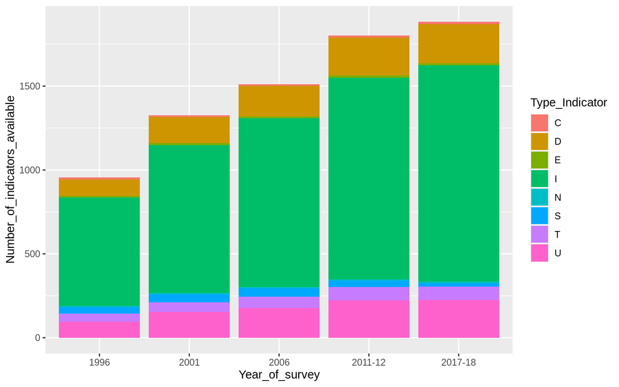

```r
# Group by Survey and indicator
  temp <- aggregate(data = resp, Indicator ~ SurveyYearLabel + IndicatorId + IndicatorType, length)

  # Count Number of indicator by survey
  temp2 <- aggregate(data = temp, IndicatorId ~ SurveyYearLabel + IndicatorType, length)
  colnames(temp2) <- c("Year_of_survey", "Type_Indicator", "Number_of_indicators_available")

  # and plot the results
  library(ggplot2)
  ggplot(temp2, aes(x = Year_of_survey, y = Number_of_indicators_available,
         fill = Type_Indicator)) +
    geom_bar(stat='identity')
```

**Nombre d’indicateurs disponibles à chaque date pour le Bénin (depuis 1996) :**

```r
temp3 <- aggregate(data = temp, SurveyYearLabel ~ IndicatorId, length)
  temp3 <- temp3[temp3$SurveyYearLabel>=5,]

  # Nombre d'indicateurs présents à toutes les dates :
  print(nrow(temp3))
```

```
[1] 863
```

### 1.5.2 Donnèes aggrégées pour le Bénin ?

**Les donnèes individuelles aggégées aux départements sont directement mis à disposition.**

Exemple pour l’indicateur “Total fertility rate 15-49” (*FE_FRTR_W_TFR*), en 2012 :

```r
resp2 <- dhs_data(indicatorIds = "FE_FRTR_W_TFR",
                   surveyYearStart = 2012,
                   surveyYearEnd = 2012,
                   breakdown = "subnational",
                   countryIds = "BJ")


  datatable(resp2[, c("CharacteristicLabel", "Value")],
            options = list(autoWidth = TRUE,
                           rownames = FALSE,
                           pageLength = 18))
```

|  | CharacteristicLabel | Value |
| --- | --- | --- |
| 1 | Atacora/Donga | 5.4 |
| 2 | ..Atacora | 5.8 |
| 3 | ..Donga | 4.7 |
| 4 | Atlantique/Littoral | 4.3 |
| 5 | ..Atlantique | 5.1 |
| 6 | ..Littoral (Cotonou) | 3.6 |
| 7 | Borgou/Alibori | 5.5 |
| 8 | ..Borgou | 5.2 |
| 9 | ..Alibori | 5.8 |
| 10 | Mono/Couffo | 4.9 |

[output cut: 8 more lines]

Le données sont également aggrégées par couple de département.

**Il n’y a malheureusement pas de clef de jointure fournies dans ces extraction les relier facilement à une couche géographique…**

**Une table de correspondance est mis à disposition à ce** [**lien**](https://github.com/HuguesPecout/EXPLO_DHS_DATA/raw/main/table_passage_nom_ISO_Dep_Benin)

Pour récupérer les géométries du découpage administratif du Bénin directement depuis R, il est possible d’utiliser le package `gadmr`

```r
if(!require(remotes)) install.packages("remotes")
  if(!require(gadmr)) remotes::install_github("SpatialWorks/gadmr")

  library(gadmr)
  # Téléchargement
  benin_sp <- get_geopackage(country = "BEN",  layer = 1)
```

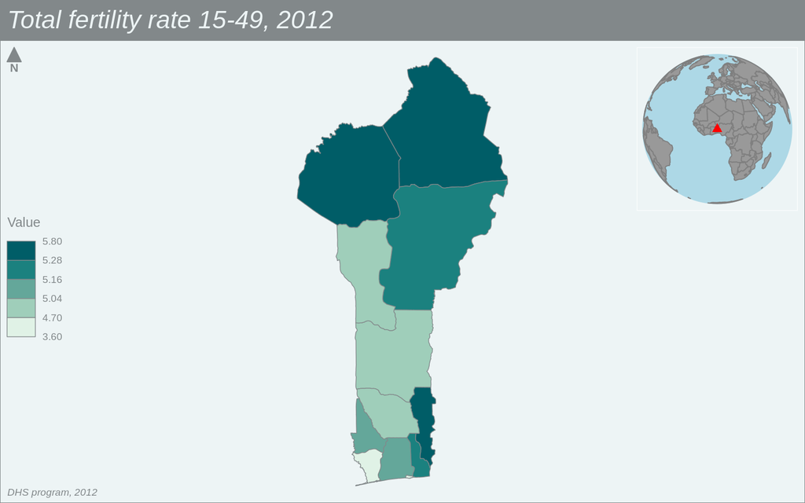

```r
# Conversion objet sp to sf
  library(sf)
  benin_sf <- st_as_sf(benin_sp)

  # Chargement table de correspondance (à télécharger)
  table <- readRDS("table_passage_nom_ISO_Dep_Benin")

  # Merge avec la table de correspondance
  benin_sf <- merge(benin_sf, table, by.x="HASC_1", by.y="ISO" )

  # Merge avec les données
  benin_sf <- merge(benin_sf, resp2, by.x="NAME_dhs", by.y="CharacteristicLabel" )

  # Cartography
  library(mapsf)
  mf_theme("agolalight")
  mf_map(benin_sf, var = "Value", type = "choro", leg_pos = "left")
  mf_layout(title = "Total fertility rate 15-49, 2012",
            credits = "DHS program, 2012",
            scale = FALSE,
            arrow = TRUE,
            frame = TRUE)
  mf_inset_on(x = "worldmap")
  mf_worldmap(benin_sf)
  mf_inset_off()
```

# 2 Donnée individuelles

## 2.1 S’enregistrer

## 2.2 Exploration des donnèes

# Bibliographie

WATSON, Oliver J, FITZJOHN, Rich et EATON, Jeffrey W, 2019. rdhs: an R package to interact with The Demographic and Health Surveys (DHS) Program datasets. In : *Wellcome Open Research* [en ligne]. 2019. Vol. 4, pp. 103. DOI 10.12688/wellcomeopenres.15311.1. Disponible à l'adresse : https://wellcomeopenresearch.org/articles/4-103/v1.

# Annexes

## Infos session

| setting | value |
| --- | --- |
| version | R version 4.0.2 (2020-06-22) |
| os | Ubuntu 18.04.5 LTS |
| system | x86_64, linux-gnu |
| ui | X11 |
| language | (EN) |
| collate | fr_FR.UTF-8 |
| ctype | fr_FR.UTF-8 |
| tz | Europe/Paris |
| date | 2021-09-17 |

| package | ondiskversion | source |
| --- | --- | --- |
| DT | 0.15 | CRAN (R 4.0.2) |
| gadmr | 0.1.0 | Github (SpatialWorks/gadmr@f4449af) |
| ggplot2 | 3.3.3 | CRAN (R 4.0.2) |
| haven | 2.4.1 | CRAN (R 4.0.2) |
| knitr | 1.33 | CRAN (R 4.0.2) |
| mapsf | 0.1.1 | CRAN (R 4.0.2) |
| rdhs | 0.7.3 | CRAN (R 4.0.2) |
| remotes | 2.3.0 | CRAN (R 4.0.2) |
| rmarkdown | 2.9 | CRAN (R 4.0.2) |
| rzine | 0.1.0 | local |
| sf | 0.9.8 | CRAN (R 4.0.2) |
| sjlabelled | 1.1.8 | CRAN (R 4.0.2) |
| xlsx | 0.6.5 | CRAN (R 4.0.2) |